# Problem Set 6 - Closing Back Doors (Answer Key)

Joe Ornstein

10/21/2021

## Problem 1

Countries with abundant natural resources like oil or mining are more likely to be authoritarian (Ross 1999)[^1] and face greater problems with political corruption (Knutsen et al. 2017). This could be an important alternative explanation for why democracies are less corrupt on average.

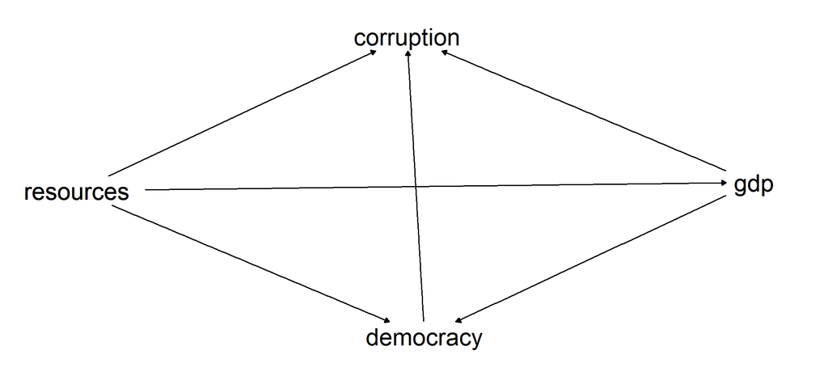

```r
# load packages
library(tidyverse)
library(janitor)
library(dagitty)
library(ggdag)
library(ggrepel)
library(here)

dag1 <- dagify(corruption ~ democracy + gdp + resources,
               gdp ~ resources,
               democracy ~ gdp + resources)

ggdag_classic(dag1) +
  theme_dag()
```

```r
adjustmentSets(dag1, exposure = 'democracy', outcome = 'corruption')
```

```
## { gdp, resources }
```

To condition on natural resource dependence, we need a measure like percent of GDP derived from resource extraction. The World Bank has such a measure [here](https://data.worldbank.org/indicator/NY.GDP.TOTL.RT.ZS). Let’s merge it with our existing corruption dataset.

```r
natural_resources <- read_csv('API_NY.GDP.TOTL.RT.ZS_DS2_en_csv_v2_3053187.csv',
                              skip = 4) %>%
  clean_names() %>%
  select(iso3 = country_code, pct_resources = x2017)

corruption_data <- read_csv(here('data/week-09/corruption-data.csv'))

d <- left_join(corruption_data, natural_resources, by = 'iso3')
```

Countries with greater shares of GDP coming from natural resources are more authoritarian on average:

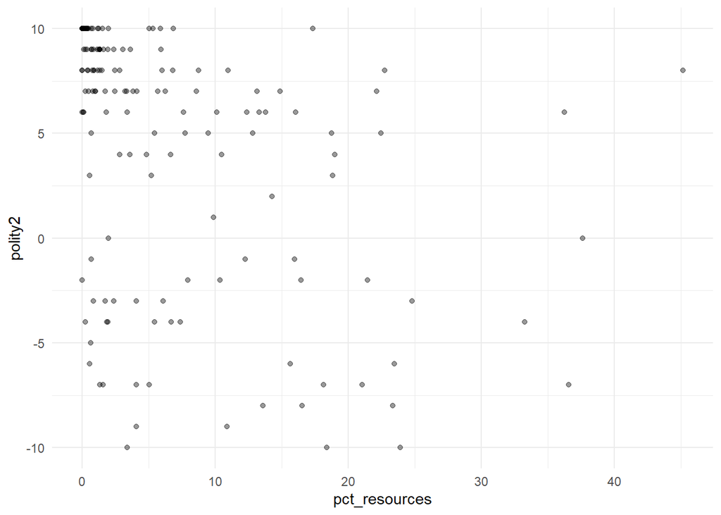

```r
ggplot(data = d,
       mapping = aes(x = pct_resources,
                     y = polity2)) +
  geom_point(alpha = 0.4) +
  theme_minimal()
```

And more corrupt on average:

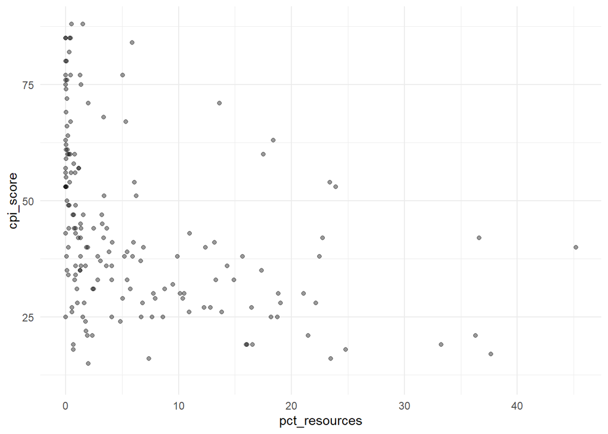

```r
ggplot(data = d,
       mapping = aes(x = pct_resources,
                     y = cpi_score)) +
  geom_point(alpha = 0.4) +
  theme_minimal()
```

Here’s the estimated relationship between corruption and democracy when we condition on (1) nothing, (2) GDP only, and (3) GDP and natural resource wealth.

```r
lm(cpi_score ~ democracy, data = d)
```

```
##
## Call:
## lm(formula = cpi_score ~ democracy, data = d)
##
## Coefficients:
## (Intercept)    democracy
##       32.09        15.61
```

```r
lm(cpi_score ~ democracy + gdp_per_capita, data = d)
```

```
##
## Call:
## lm(formula = cpi_score ~ democracy + gdp_per_capita, data = d)
##
## Coefficients:
##    (Intercept)       democracy  gdp_per_capita
##      2.367e+01       8.873e+00       6.238e-04
```

```r
lm(cpi_score ~ democracy + gdp_per_capita + pct_resources, data = d)
```

```
##
## Call:
## lm(formula = cpi_score ~ democracy + gdp_per_capita + pct_resources,
##     data = d)
##
## Coefficients:
##    (Intercept)       democracy  gdp_per_capita   pct_resources
##      27.436709        7.114950        0.000601       -0.312750
```

The estimated relationship between democracy and corruption perceptions is further attenuated, though it remains positive.

## Problem 2

First, load the behavioral data from Cohn et al. (2019).

```r
wallets <- read_csv( here('data/cohn-2019/behavioral data (csv file).csv') )
```

What fraction of the wallets were returned in each country?

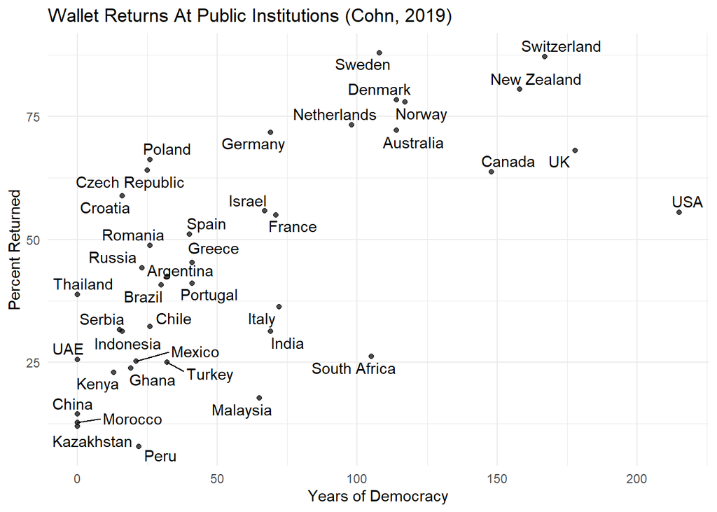

```r
wallets_summary <- wallets %>%
  # keep only the public institutions
  filter(public == 1) %>%
  # compute the average response rate by country
  group_by(Country, c_PIV_years_democracy) %>%
  summarize(pct_returned = mean(response))

# plot the relationship between democracy and wallet stealing
p <- ggplot(data = wallets_summary,
            mapping = aes(x = c_PIV_years_democracy,
                          y = pct_returned,
                          label = Country)) +
  geom_point(alpha = 0.7) +
  geom_text_repel() +
  labs(x = 'Years of Democracy',
       y = 'Percent Returned',
       title = 'Wallet Returns At Public Institutions (Cohn, 2019)') +
  theme_minimal()

p
```

```r
lm(pct_returned ~ c_PIV_years_democracy,
   data = wallets_summary)
```

```
##
## Call:
## lm(formula = pct_returned ~ c_PIV_years_democracy, data = wallets_summary)
##
## Coefficients:
##           (Intercept)  c_PIV_years_democracy
##               29.9250                 0.2703
```

The rate at which bureaucrats return wallets is higher in traditionally democratic countries. But we cannot interpret that relationship as causal, even though the data comes from an experiment. The experiment randomized *who* received wallets and whether there was money in the wallet, but could not, of course, randomize the political institutions of a country. The observed relationship between democracy and wallet returning could be confounded by any number of variables outside the control of the experimenters.

## Problem 3 (Bonus Fun)

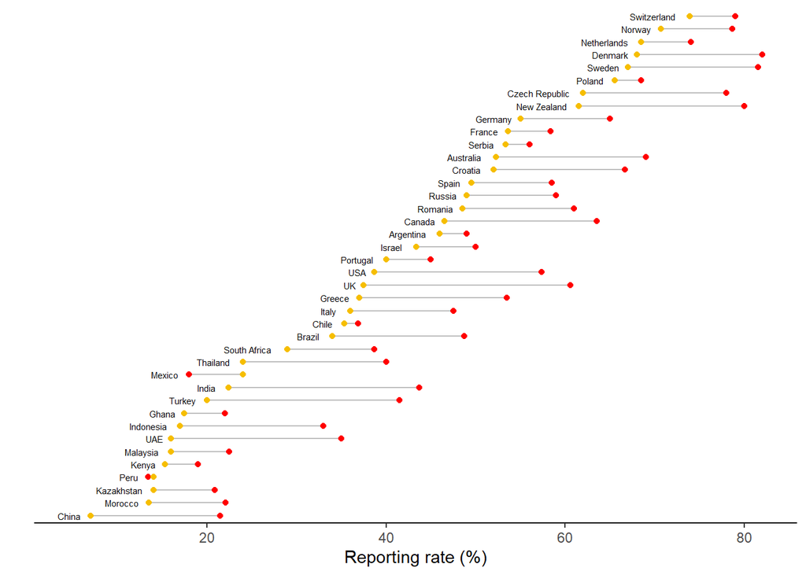

```r
fig1a <- wallets %>%
  filter(cond %in% c(0,1)) %>%
  mutate(cond = case_when(cond == 1 ~ 'Money',
                          cond == 0 ~ 'NoMoney')) %>%
  # compute reporting rate by country and monetary condition
  group_by(Country,
           cond) %>%
  summarize(pct_reported = mean(response)) %>%
  # pivot_wider to make those line segments
  ungroup %>%
  pivot_wider(names_from = cond, values_from = pct_reported) %>%
  # reorder Country by the NoMoney reporting rate
  mutate(Country = fct_reorder(Country, NoMoney)) %>%
  # compute label position, left of the minimum reporting rate
  mutate(label_position = pmin(Money, NoMoney) -
           nchar(as.character(Country))/3.5 - 1) %>%
  # begin ggplot
  ggplot() +
  geom_segment(aes(x=Money, xend=NoMoney, y=Country, yend=Country),
               color = 'gray', size = 0.5) +
  geom_point(aes(x=Money,y=Country), color = 'red') +
  geom_point(aes(x=NoMoney,y=Country), color = '#F6BE00') +
  geom_text(aes(x=label_position, y=Country, label = Country), size = 2) +
  labs(x = 'Reporting rate (%)', y = '', color = 'Condition') +
  theme_classic() +
  theme(axis.text.y = element_blank(),
        axis.ticks.y = element_blank(),
        axis.line.y = element_blank())

fig1a
```

## References

Cohn, Alain, Michel André Maréchal, David Tannenbaum, and Christian Lukas Zünd. 2019. “Civic Honesty Around the Globe.” *Science* 365 (6448): 70–73. https://doi.org/10.1126/science.aau8712.

Haber, Sephen, and Victor Menaldo. 2011. “Do Natural Resources Fuel Authoritarianism? A Preappraisal of the Resource Curse.” *American Political Science Review* 105 (1): 1–26. https://doi.org/10.1017/S0003055410000584.

Knutsen, Carl Henrik, Andreas Kotsadam, Eivind Hammersmark Olsen, and Tore Wig. 2017. “Mining and Local Corruption in Africa.” *American Journal of Political Science* 61 (2): 320–34. https://doi.org/10.1111/ajps.12268.

Ross, Michael L. 1999. “The Political Economy of the Resource Curse.” *World Politics* 51: 297–322. https://doi.org/10.2307/25054077.

[^1]: Though see Haber and Menaldo (2011) for a critical appraisal of the resource curse literature.